# Kaggle: Springleaf Marketing Response

Liudmila Dzemiantsova

October 8, 2015

**Description**

The Website of the Kaggle competition is https://www.kaggle.com/c/springleaf-marketing-response. Springleaf puts the humanity back into lending by offering their customers personal and auto loans that help them take control of their lives and their finances. Direct mail is one important way Springleaf’s team can connect with customers whom may be in need of a loan. In order to improve their targeted efforts, Springleaf must be sure they are focusing on the customers who are likely to respond and be good candidates for their services.

**Task**

Using a large set of anonymized features, Springleaf is asking you to predict which customers will respond to a direct mail offer. Submissions are evaluated on area under the ROC curve between the predicted probability and the observed target.

**Programming and Software**

The prediction model is written with R v.3.2.1 using RStudio v.0.99.484

**Libraries**

```r
source("makePrediction.R")
source("multiplot.R")
source("makePlot.R")
source("mapStates.R")
```

[output not shown]

[output not shown]

**Read the training data**

```r
registerDoParallel(cores=1)
training <- read_csv("train.csv")
```

**Unbalanced target**

```r
training <- training[,-1]
target <- training[,1933]
training <- training[,-1933]
dim(training)
```

```
## [1] 145231   1932
```

```r
for (i in 1:length(target)) ifelse(target[i] == 0, target[i] <- "no", target[i] <- "yes")
target <- as.factor(target)
df <- data.frame(table(target))
colnames(df) <- c('Target','Freq')
df$Perc <- df$Freq / sum(df$Freq) * 100
df
```

```
##   Target   Freq     Perc
## 1     no 111458 76.74532
## 2    yes  33773 23.25468
```

**Splitting the data**

```r
set.seed(123)
inTrain <- createDataPartition(y = target, p = 0.1, list = FALSE)
validation <- training[-inTrain,]
training <- training[inTrain,]
target.train <- target[inTrain]
target.valid <- target[-inTrain]
```

**Cleaning the data**

```r
training[training==""] = NA
training[training=="[]"] = NA
training[training=="-1"] = NA
training[training==-1] = NA
training[training==-99999] = NA
training[training==999999999] = NA
training[training==999999998] = NA
training[training==999999997] = NA
training[training==999999996] = NA
training[training==9999] = NA
training[training==9998] = NA
training[training==9997] = NA
training[training==9996] = NA
```

**Exploring the data using plots**

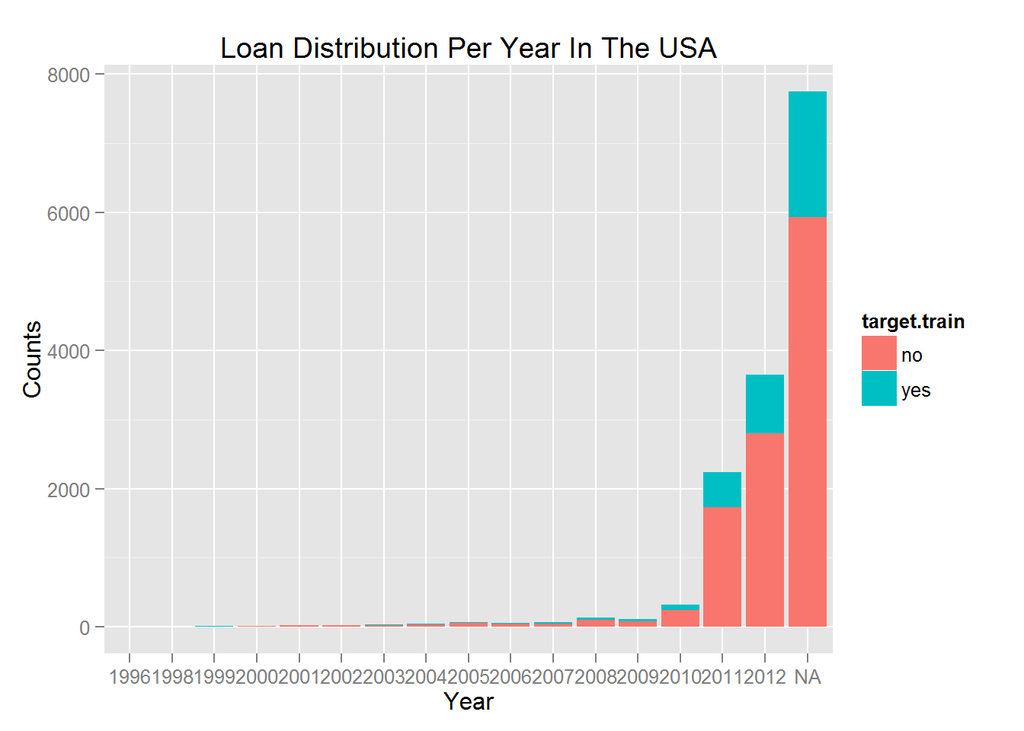

```r
qplot(as.factor(VAR_0332),data=training,fill=target.train, main="                  Loan Distribution Per Year In The USA                  ", xlab="Year", ylab="Counts")
```

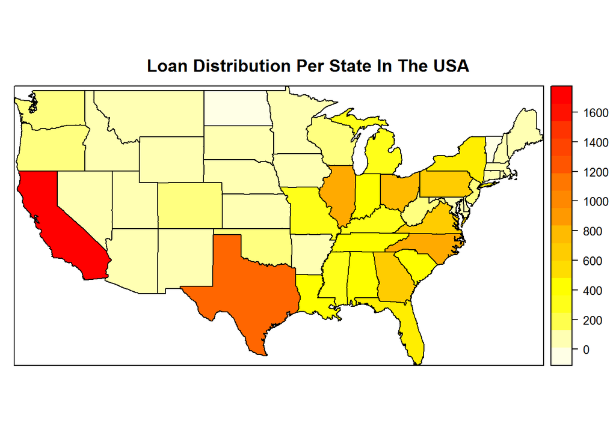

```r
mapStates(training, "VAR_0274")
```

**Pre-processing the data**

```r
load("mostlyData.rda")
if (file.exists("mostlyData.rda")) {
  load("mostlyData.rda")
} else {
  mostlyData<-apply(!is.na(training),2,sum)>(dim(training)[1]-1)
  save(mostlyData, file="mostlyData.rda")
}
training<-training[,mostlyData]

if (file.exists("zeroTrain.rda")) {
  load("zeroTrain.rda")
} else {
  zeroTrain <- nearZeroVar(training)
  save(zeroTrain, file="zeroTrain.rda")
}
training <- training[, -zeroTrain]

training_numr = training[, sapply(training, is.numeric)]
training_char = training[, sapply(training, is.character)]
rm(training)
for(i in 1:(dim(training_char)[2])){
    training_char[,i] <- as.integer(as.factor(training_char[,i]))
}
training_numr <- data.frame(training_numr, training_char)
rm(training_char)
```

I remove those predictors that result in absolute pairwise correlation greater than a threshold of 0.9.

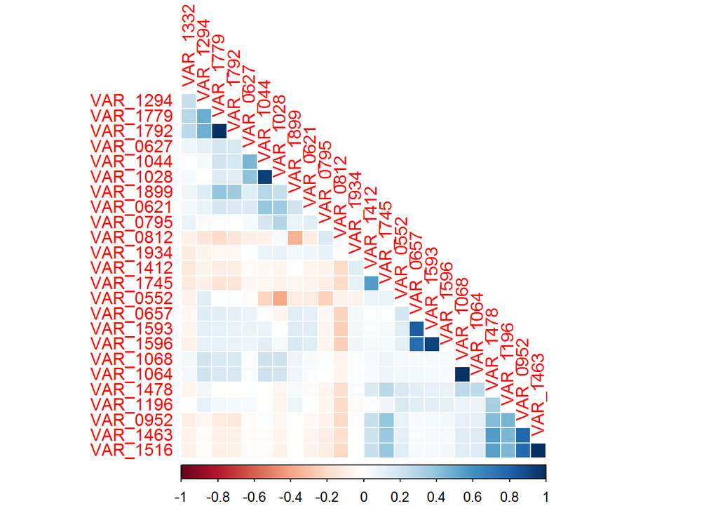

```r
set.seed(333)
training_samp = training_numr[,sample(1:ncol(training_numr),25)]
makePlot(training_samp, 1)
```

```r
rm(training_samp)

if (file.exists("highCorr.rda")) {
  load("highCorr.rda")
} else {
  Corr <- cor(training_numr, method = "pearson")
  highCorr <- findCorrelation(Corr, 0.9)
  save(highCorr, file="highCorr.rda")
}
training_numr <- training_numr[, -highCorr]
```

Last, the predictor variables are centered and scaled.

```r
if (file.exists("xTrans.rda")) {
  load("xTrans.rda")
} else {
  xTrans <- preProcess(training_numr)
  save(xTrans, file="xTrans.rda")
}
training_numr<- predict(xTrans, training_numr)
```

**Building supervised lerning models**

I use different supervised lerning methods:

1. extreme gradient boosting (xgb)

```r
set.seed(1)
cvControl <- trainControl(method = "repeatedcv", repeats=5, summaryFunction = twoClassSummary, classProbs = TRUE)
if (file.exists("xgbFit.rda")) {
  load("xgbFit.rda")
} else {
  xgbFit <- train(training_numr, target, method = "xgbTree", metric = "ROC", trControl = cvControl)
  save(xgbFit, file="xgbFit.rda")
}
print(xgbFit)
```

```
## eXtreme Gradient Boosting
##
## 145231 samples
##    225 predictor
##      2 classes: 'no', 'yes'
##
## No pre-processing
## Resampling: Cross-Validated (10 fold, repeated 5 times)
## Summary of sample sizes: 130708, 130708, 130708, 130708, 130707, 130708, ...
## Resampling results across tuning parameters:
##
##   max_depth  nrounds  ROC        Sens       Spec       ROC SD
##   1           50      0.7301620  0.9781855  0.1124746  0.004520728
##   1          100      0.7376812  0.9679090  0.1592693  0.004270278
##   1          150      0.7402221  0.9643848  0.1753710  0.004242134
##   2           50      0.7417822  0.9660751  0.1752939  0.003928024
##   2          100      0.7471186  0.9595004  0.2045422  0.003903744
##   2          150      0.7495075  0.9575463  0.2153555  0.003962356
##   3           50      0.7475879  0.9601644  0.2041039  0.003900320
##   3          100      0.7513263  0.9557448  0.2246174  0.003759817
##   3          150      0.7527196  0.9538427  0.2334588  0.003650453
##   Sens SD      Spec SD
##   0.001591675  0.005522769
##   0.001741511  0.007158357
##   0.001913395  0.006958009
##   0.001958416  0.007078460
##   0.001851431  0.006648868
##   0.001844463  0.007230733
##   0.002026764  0.007462167
##   0.001910736  0.008169650
##   0.002325419  0.007558085
##
## Tuning parameter 'eta' was held constant at a value of 0.3
## ROC was used to select the optimal model using  the largest value.
## The final values used for the model were nrounds = 150, max_depth = 3
##  and eta = 0.3.
```

2. random forest (rf)

```r
if (file.exists("rfFit.rda")) {
  load("rfFit.rda")
} else {
  rfFit <- train(training_numr, target.train, method = "rf", metric = "ROC", trControl = cvControl)
  save(rfFit, file="rfFit.rda")
}
print(rfFit)
```

```
## Random Forest
##
## 14524 samples
##   225 predictor
##     2 classes: 'no', 'yes'
##
## No pre-processing
## Resampling: Cross-Validated (10 fold, repeated 5 times)
## Summary of sample sizes: 13072, 13071, 13071, 13071, 13072, 13072, ...
## Resampling results across tuning parameters:
##
##   mtry  ROC        Sens       Spec        ROC SD      Sens SD
##     2   0.7198348  0.9946886  0.04162046  0.01550178  0.002450973
##   113   0.7285520  0.9713797  0.15020561  0.01327534  0.004743148
##   225   0.7260371  0.9664454  0.15932260  0.01387418  0.005530485
##   Spec SD
##   0.009900861
##   0.017829178
##   0.018503735
##
## ROC was used to select the optimal model using  the largest value.
## The final value used for the model was mtry = 113.
```

3. k-nearest neighbors (knn)

```r
knnGrid <- expand.grid(.k=c(1:10))
if (file.exists("knnFit.rda")) {
  load("knnFit.rda")
} else {
  rfFit <- train(training_numr, target.train, method = "knn", metric = "ROC", trControl = cvControl, tuneGrid = knnGrid)
  save(knnFit, file="knnFit.rda")
}
print(knnFit$finalModel)
```

```
## 8-nearest neighbor classification model
## Training set class distribution:
##
##    no   yes
## 11146  3378
```

**Makeing predictions**

To estimate the efficiency of different models, I make predictions for 10% of the validation data, and compare the results with true targets.

```r
set.seed(567)
inValid <- createDataPartition(y = target.valid, p = 0.1, list = FALSE)
validation <- validation[inValid,]
target.valid <- target.valid[inValid]
set.seed(7)
predictions.xgb <- makePrediction(validation, xgbFit, "none")
set.seed(7)
predictions.rf <- makePrediction(validation, rfFit, "none")
set.seed(7)
predictions.knn <- makePrediction(validation, knnFit, "none")

set.seed(7)
predictions.xgb.prob <- makePrediction(validation, xgbFit, "prob")
set.seed(7)
predictions.rf.prob <- makePrediction(validation, rfFit$finalModel, "prob")
set.seed(7)
predictions.knn.prob <- makePrediction(validation, knnFit$finalModel, "prob")
```

**ROC curves**

```r
ROC.xgb <- roc(predictor = predictions.xgb.prob[,"yes"], response = target.valid, levels = rev(levels(target.valid)))
ROC.rf <- roc(predictor = predictions.rf.prob[,"yes"], response = target.valid, levels = rev(levels(target.valid)))
ROC.knn <- roc(predictor = predictions.knn.prob[,"yes"], response = target.valid, levels = rev(levels(target.valid)))

plot(ROC.xgb, type = "S", col = "red", print.thres = .5)
```

```
##
## Call:
## roc.default(response = target.valid, predictor = predictions.xgb.prob[,     "yes"], levels = rev(levels(target.valid)))
##
## Data: predictions.xgb.prob[, "yes"] in 3040 controls (target.valid yes) > 10032 cases (target.valid no).
## Area under the curve: 0.7666
```

```r
plot(ROC.rf, add = T, col = "green")
```

```
##
## Call:
## roc.default(response = target.valid, predictor = predictions.rf.prob[,     "yes"], levels = rev(levels(target.valid)))
##
## Data: predictions.rf.prob[, "yes"] in 3040 controls (target.valid yes) > 10032 cases (target.valid no).
## Area under the curve: 0.7182
```

```r
plot(ROC.knn, add = T, col = "blue")
```

```
##
## Call:
## roc.default(response = target.valid, predictor = predictions.knn.prob[,     "yes"], levels = rev(levels(target.valid)))
##
## Data: predictions.knn.prob[, "yes"] in 3040 controls (target.valid yes) > 10032 cases (target.valid no).
## Area under the curve: 0.6201
```

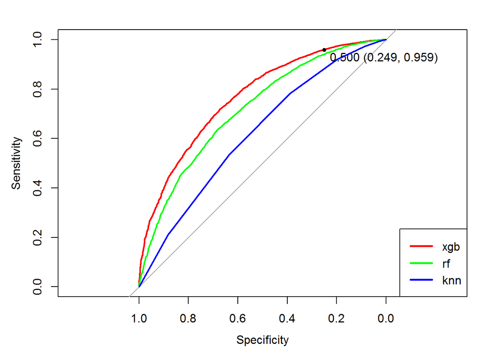

```r
legend("bottomright",c("xgb","rf","knn"), lwd=c(2.5,2.5,2.5), col=c("red","green", "blue"))
```

**The best model**

```r
xgb.model <- data.frame(model ="xgb", "error"=mean(predictions.xgb != target.valid), "auc"=ROC.xgb$auc)
rf.model <- data.frame(model = "rf", "error"=mean(predictions.rf != target.valid), "auc"=ROC.rf$auc)
knn.model <- data.frame(model = "knn", "error"=mean(predictions.knn != target.valid), "auc"=ROC.knn$auc)
all.model <- rbind(xgb.model, rf.model, knn.model)
all.model
```

```
##   model     error       auc
## 1   xgb 0.2063188 0.7666070
## 2    rf 0.2153458 0.7181786
## 3   knn 0.2408201 0.6201494
```

**Most important predictors**

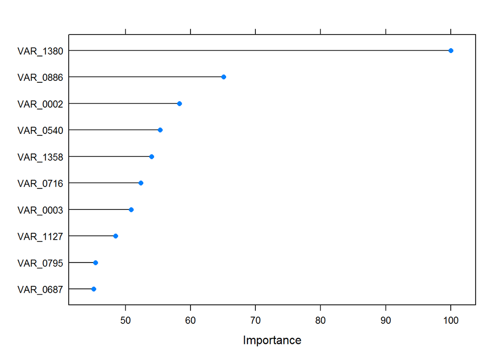

```r
valImp <- varImp(rfFit, scale = TRUE)
plot(valImp, top = 10)
```

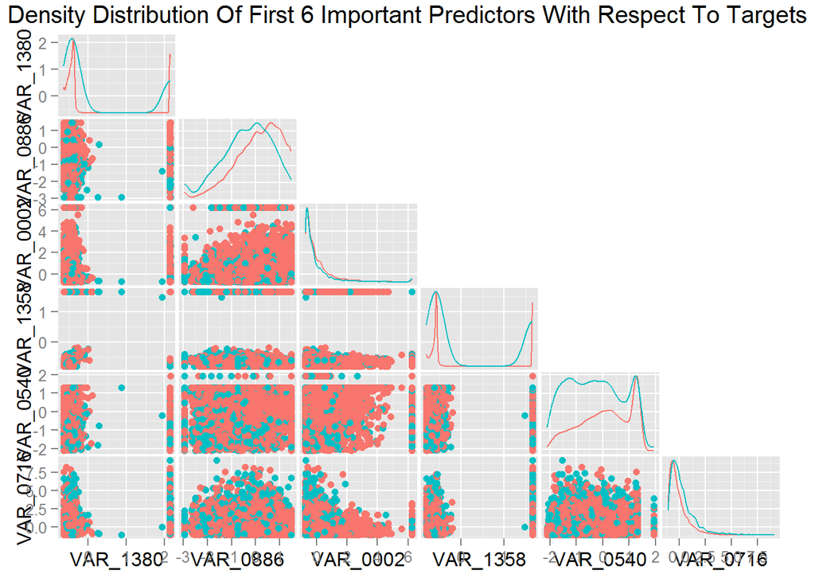

```r
training.plot <- data.frame(training_numr, target=target.train)
makePlot(training.plot, 2)
```

```r
rm(training.plot)
```